# Analise IMDB

Katerine Witkoski

# Meu caderno de instruções nº 1

Vamos fazer nossa primeira análise de dados, e eu Katerine vou tentar auxiliar vocês nessa jornada. Nosso objetivo é impressionar dois produtores de filmes e auxiliar eles a identificar qual seria o melhor filme para esse ano obtendo sucesso financeiro e reconhecimento da crítica. Vamos ajuda-los a concorrer o Oscar de 2021!!

O nosso primeiro passo é importar os dados, no meu caso minha base se encontrava na pasta data_raw no formato `.rds`.

## Importanto base

```r
imdb <- readr::read_rds("data_raw/imdb.rds")
```

Aqui nos importamos usando o pacote `readr` ultilizando a expressão `::`com a função `readr_rds` específica para importar arquivos no formato `rds`.

Vamos carregar os pacotes para esse projeto:

```r
library(tidyverse)
library(ggplot2)
library(RColorBrewer)
library(ggthemes)
```

Usamos a função `glimpse` uma função do pacote `tidyverse` para visualisar todas as informações da base, ela mostra as suas váriaveis e suas características. Com essas informações será mais fácil chegar a uma tomada de decisão na sua analise. Portanto temos que observar os seguintes pontos quais são as melhores notas, melhores atores (eles estão relacionados), melhores diretores e o genêro que mais teve notas altas.

```r
glimpse(imdb)
```

```
## Rows: 3,713
## Columns: 15
## $ titulo         <chr> "Avatar", "Pirates of the Caribbean: At World's End", …
## $ ano            <int> 2009, 2007, 2012, 2012, 2007, 2010, 2015, 2016, 2006, …
## $ diretor        <chr> "James Cameron", "Gore Verbinski", "Christopher Nolan"…
## $ duracao        <int> 178, 169, 164, 132, 156, 100, 141, 183, 169, 151, 150,…
## $ cor            <chr> "Color", "Color", "Color", "Color", "Color", "Color", …
## $ generos        <chr> "Action|Adventure|Fantasy|Sci-Fi", "Action|Adventure|F…
## $ pais           <chr> "USA", "USA", "USA", "USA", "USA", "USA", "USA", "USA"…
## $ classificacao  <chr> "A partir de 13 anos", "A partir de 13 anos", "A parti…
## $ orcamento      <int> 237000000, 300000000, 250000000, 263700000, 258000000,…
## $ receita        <int> 760505847, 309404152, 448130642, 73058679, 336530303, …
## $ nota_imdb      <dbl> 7.9, 7.1, 8.5, 6.6, 6.2, 7.8, 7.5, 6.9, 6.1, 7.3, 6.5,…
## $ likes_facebook <int> 33000, 0, 164000, 24000, 0, 29000, 118000, 197000, 0, …
## $ ator_1         <chr> "CCH Pounder", "Johnny Depp", "Tom Hardy", "Daryl Saba…
## $ ator_2         <chr> "Joel David Moore", "Orlando Bloom", "Christian Bale",…
## $ ator_3         <chr> "Wes Studi", "Jack Davenport", "Joseph Gordon-Levitt",…
```

## Entendendo a problemática

Conhecendo as caracteristicas da base podemos chegar nas seguintes conclusões:

1. Quais são os Top 10 filmes?
2. Qual é relação entre a Receita e o Orçamento do filme? Houve lucro?
3. Lucro dos filmes com as melhores notas?
4. Qual são os 5 maiores Diretores? Qual é a relação de lucro entre eles?
5. Qual é a duração de um filme de sucesso?
6. Quais são os 10 melhores atores? Qual é a nota média deles?
7. Quais são os genênos mais badalados?

## Explorando a base e manipulando dados

Antes de tudo criamos uma lógica em que *receita - orçamento* poderá me dar o lucro.

**LUCRO = receita - orçamento**

```r
imdb <- imdb %>% mutate(lucro = receita - orcamento)
```

1. Quais são os Top 10 Filmes?

| Posição | Filme | Lucro |
| --- | --- | --- |
| 1 | Avatar | $523,505,847 |
| 2 | Jurassic World | $502,177,271 |
| 3 | Titanic | $458,672,302 |
| 4 | Star Wars: Episode IV - A New Hope | $449,935,665 |
| 5 | E.T. the Extra-Terrestrial | $424,449,459 |
| 6 | The Avengers | $403,279,547 |
| 7 | The Lion King | $377,783,777 |
| 8 | Star Wars: Episode I - The Phantom Menace | $359,544,677 |
| 9 | The Dark Knight | $348,316,061 |
| 10 | The Hunger Games | $329,999,255 |

Observamos que pela análise temos como o melhor classificado o Avatar, escrito e dirigido por James Cameron, seu lucro foi de 523505,847 dólares. Avatar foi nomeado em nove categorias do Oscar, incluido Melhor Filme e Melhor Diretor, porém foi premiado apenas em três categorias: Melhor Fotografia, Melhores Efeitos Visuais e Melhor Direção de Arte. Chique demais, quem não pegou aquela sessão 3D que era mega novidade para assitir o lançamento?? Foi emocionante!

### Criando uma função de tema

Para padronizar os gráficos eu criei um tema base:

```r
tema_analise <- function() {
  theme(
    text = element_text(
      color = "#4ABDAC",
      size = 10),
    plot.title = element_text(
      colour = "#FC4A1A",
      hjust = 0.5,
      size = 20),
    panel.background = element_rect(fill = "#DFDCE3"),
    legend.position = "bottom")
}
```

2. Qual é relação entre a Receita e o Orçamento do filme?

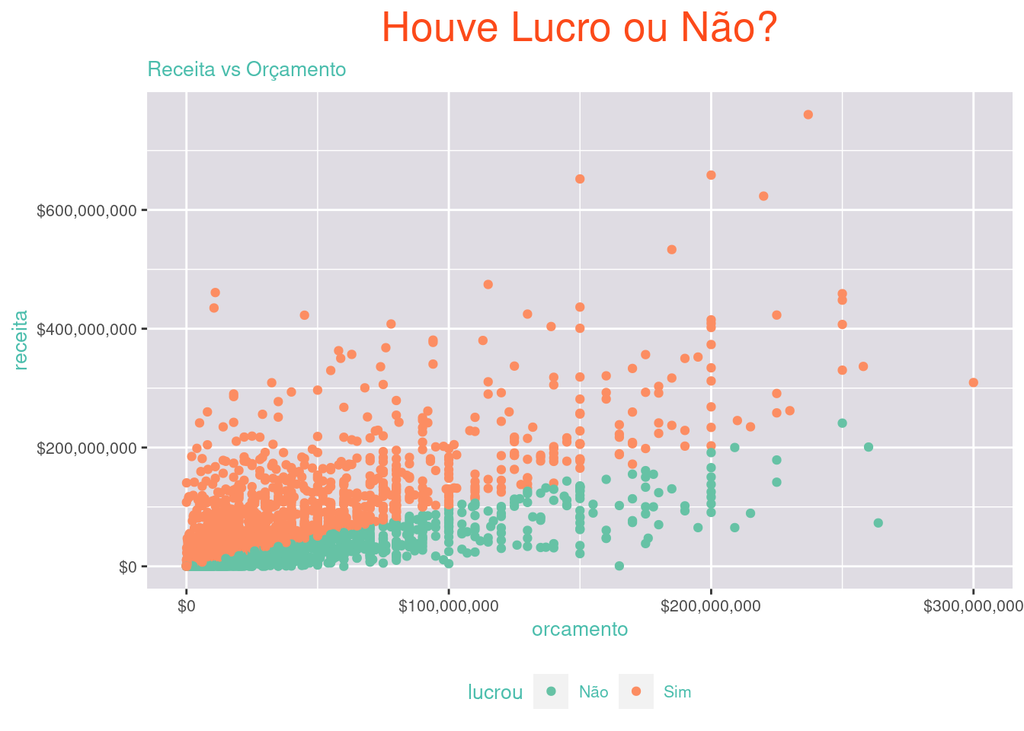

3. Lucro dos filmes com as melhores notas?

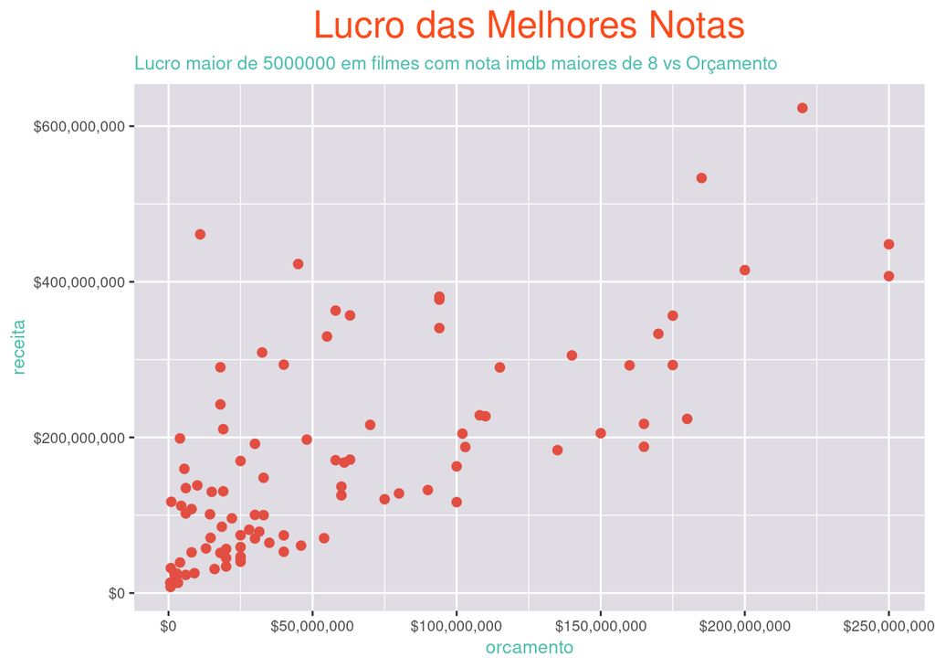

Nesse gráfico obsevamos que a relação entre os pontos um crescimento linear, contendo uma distância relevante entre elas, a qual faz entender que existe uma possivel correlação positiva entre as váriaveis *receita e orçamento*, significando que a variável afeta positivamente a outra.

4. Qual são os 5 maiores Diretores? Qual é a relação de lucro entre eles?

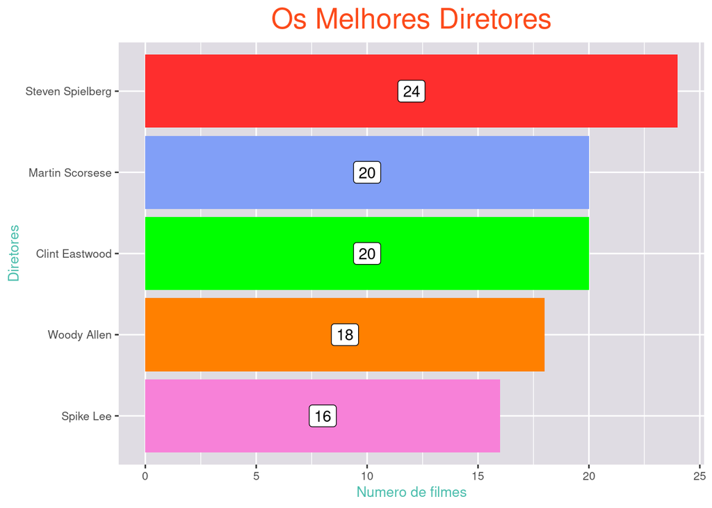

Com esse gráfico de colunas, para os amantes de cinema, temos uma boa notícia. Classificamos os melhores Diretores:

- Steven Spilberg, diretor dos filmes que você provavelmente já assistiu 567864 vezes em alguma sessão na TV aberta como “E.T.: O Extraterreste”, “Tubarão”, “Contatos Imediatos”, entre outros;
- Martin Scorsese, o diretor mais “gangster, com os filmes queridinhos do cinema como”Taxi- Driver“,”Os Infiltrados“,”O irlandês", entre outros;
- Clint Eastwood, o diretor mais bang-bang da lista, produtor de filmes como “Os Imperdoáveis”, “Sniper Americano”, mas não podemos esquecer das interpretações como ator em filmes com a temática faroeste, o mais memorável “Três Homens em Comflito”. E acredita TODO filme de foroeste terá a famosa trilha sonora composta pelo Ennio Morricone, feita exclusivamente para seu tema principal;
- Woody Allen, aquele diretor mais meloso e carismático com suas comédias romanticas “Annie Hall” e “Manhattan”, para quem curte um momento fofura ele é uma ótima sugestão;
- Spike Lee, um diretor que tem discursos fortes contra o preconceito racial, ele trás reflexão em filmes como “Ela quer tudo”, “Malcom X”, “Quatro Meninas: Uma história real”, entre outros;

e vamos falar de lucro…

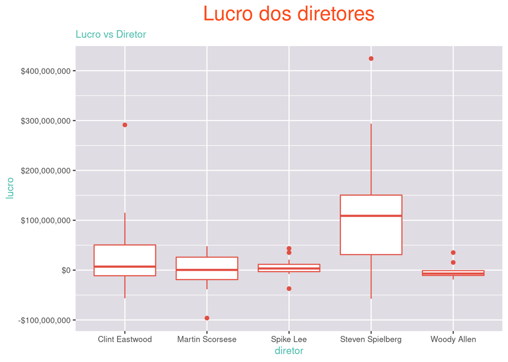

5. Qual é a duração de um filme de sucesso?

Se há algum tempo apenas grandes épicos e filmes históricos costumavam passar das 2 horas e meia, agora não há mais um limite para gêneros, mas sabemos que para concorrer ao Oscar somente 40 minutos de filmagem já é o suficiente para ser indicado.

Portanto podemos analisar:

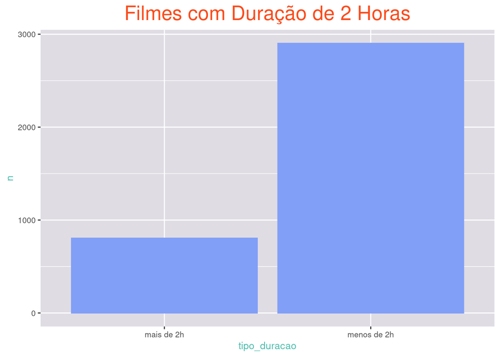

Entre os filmes da base observamos que a maioria contém uma duração de menos de 2 horas.

6. Quais são os 10 melhores atores? Qual é a nota média deles?

Um filmão precisa que um ator a altura, alguém versátil de uma atuação mais de tirar o folego e menos Kristen Stewart no filme “Crepúsculo”.

Realizei uma análise da média das notas entre os melhores atores relacionados a filmes com notas acima de 8:

```
## # A tibble: 640 x 4
## # Groups:   ator, nota_imdb [640]
##    ator           nota_imdb data             media_das_notas
##    <chr>              <dbl> <list>                     <dbl>
##  1 Morgan Freeman       9.3 <tibble [1 × 0]>             9.3
##  2 Jeffrey DeMunn       9.3 <tibble [1 × 0]>             9.3
##  3 Bob Gunton           9.3 <tibble [1 × 0]>             9.3
##  4 Al Pacino            9.2 <tibble [1 × 0]>             9.2
##  5 Marlon Brando        9.2 <tibble [1 × 0]>             9.2
##  6 Robert Duvall        9.2 <tibble [1 × 0]>             9.2
##  7 Matthew Ziff         9.1 <tibble [1 × 0]>             9.1
##  8 T.J. Storm           9.1 <tibble [1 × 0]>             9.1
##  9 Sam Medina           9.1 <tibble [1 × 0]>             9.1
## 10 Christian Bale       9   <tibble [1 × 0]>             9
## # … with 630 more rows
```

Concluindo os 5 melhores:

| Atores | Media das notas |
| --- | --- |
| Morgan Freeman | 9.3 |
| Jeffrey DeMunn | 9.3 |
| Bob Gunton | 9.3 |
| Al Pacino | 9.2 |
| Marlon Brando | 9.2 |

7. Quais são os genênos mais badalados? Está na hora de decidir, tem muitos tipos de gêneros de filmes e cada um deles desperta uma sensação diferente na hora de assistir, e aqui podemos ver qual é o genêro mais queridinho:

| generos | n |
| --- | --- |
| Comedy | 185 |
| Comedy\|Drama | 152 |
| Comedy\|Drama\|Romance | 149 |
| Comedy\|Romance | 135 |
| Drama | 166 |

Observamos que o gênero que alcançou o coração do telespectador é o Comédia.

Mas vamos pensar no lucro:

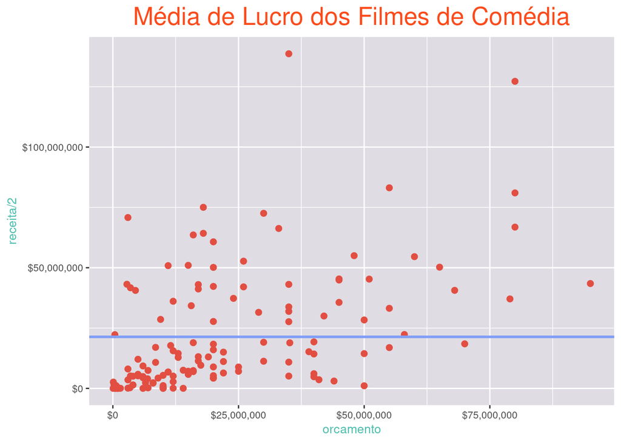

A média do lucro está perto do 25.000,000 e nesse gráfico podemos ver que boa parte dos filmes atingiram a meta para o sucesso.

## Conclusão

Para um filme de sucesso, além da criatividade dos produtores chegamos na conclusão que a fim de criar uma experiência incrivel em meio desses tempos de pandemia. Faremos o pessoal rir um pouco com o gênero **Comédia**, na direção do nosso queridinho **Steven Spilberg**, de duração de pelo menos 2 horas ou menor, com os atores protagonistas **Morgan Freemam** e **Jeffrey DeMunn**.

[figure not shown]